# ML Project Capstone

Gaurav

2 December 2016

# 1. Summary

The Data comes from [Weight Lifting Exercises Dataset](http://groupware.les.inf.puc-rio.br/har#weight_lifting_exercises). They did a research on discriminating between different activities and how well the activity is done. Six young health participants were asked to perform one set of 10 repetitions of the Unilateral Dumbbell Biceps Curl in five different fashions: exactly according to the specification (Class A), incorrectly performed are classified into Class B, Class C, Class D, Class E. The **Goal** of this project is to analyse this data and build a prediction algorithm to correctly classify new activities into Class A, Class B, Class C, Class D, Class E. The Project demonstrates performances of different algorithms and picks one with **low out of sample error**.

*The script is reproducible.*

# 2. Getting Data

The Dataset is downloaded from coursera

```r
set.seed(12345)
if(!file.exists("./dataset")){
    dir.create("./dataset");
    fileUrl <- "https://d396qusza40orc.cloudfront.net/predmachlearn/pml-training.csv";
    download.file(fileUrl,destfile="./dataset/pml-training.csv");

    fileUrl <- "https://d396qusza40orc.cloudfront.net/predmachlearn/pml-testing.csv";
    download.file(fileUrl,destfile="./dataset/pml-testing.csv");
}
```

### Analysing Raw Data

The Downloaded Data contains 2 files *pml-training.csv*, *pml-testing.csv*. The *pml-training.csv* file contains training data and *pml-testing.csv* contains test data which we have to do prediction on.

```r
dataset <-  read.csv("./dataset/pml-training.csv", na.strings = c("","NA","NaN"))
dataPredict <- read.csv("./dataset/pml-testing.csv", na.strings = c("","NA","NaN"))
dim(dataset)
```

```
## [1] 19622   160
```

```r
dim(dataPredict)
```

```
## [1]  20 160
```

```r
table(dataset$classe)
```

```
##
##    A    B    C    D    E
## 5580 3797 3422 3216 3607
```

We can see that training data consists of **160 features** and 19622 examples. We have to do prediction on 20 examples. The division of outcome shows that there is no **skewness** in outcome variable

# 3. Cleaning

Next step is to clean raw data. We store it in “clean” directory. Cleaning procedure is as follows.

#### 1. build model on like data to predict like data

In testing dataset we have no instances of new_window = “yes”. so we are removing new_window = “yes” in training data.

```r
table(dataPredict$new_window)
```

```
##
## no
## 20
```

#### 2. Removing Columns with NA values more than 40% of column values.

If NA values are less than 40% we will impute data.

#### 3. Removing columns unnecessary columns.

Removing Columns that doesn’t add anything to data i.e. that are not significant for prediction.

```r
if(!file.exists("./dataset/clean")){
    dir.create("./dataset/clean")
    ## 2. Reading Data
    dataset <-  read.csv("./dataset/pml-training.csv", na.strings = c("","NA","NaN"))
    dataPredict <- read.csv("./dataset/pml-testing.csv", na.strings = c("","NA","NaN"))

    #! Cleaning Data !#
    ## keep like data to predict like data
    ## testing dataset consists only no values for new_window variable
    ## removing all values of yes in new_window feature in testing data
    library(dplyr)
    dataset <- filter(dataset, new_window == "no")

    ## removing columns with na values more than 40%
    dataset <- dataset %>% select_if(colSums(!is.na(.)) > 0.60 * nrow(dataset))

    ## removing columns that doesn't add anything to data
    dataset <- dataset %>% select(-c(X, raw_timestamp_part_1, raw_timestamp_part_2, cvtd_timestamp, new_window, num_window))
    # dim(dataset)
    write.csv(dataset, file = "./dataset/clean/dataset.csv")

    ## cleaning predction dataset
    dataPredict <- filter(dataPredict, new_window == "no")
    dataPredict <- dataPredict %>% select_if(colSums(!is.na(.)) > 0.60 * nrow(dataPredict))
    dataPredict <- dataPredict %>% select(-c(X, raw_timestamp_part_1, raw_timestamp_part_2, cvtd_timestamp, new_window, num_window))
    write.csv(dataPredict, file = "./dataset/clean/dataPredict.csv")
    rm(list =ls())
}
```

Now data is in desired form. We will be performing further analysis on this data.

# 4. Exploratory Data Analysis

Finally we are performing exploratory data analysis on clean data. Lets have a look at the data.

```r
library(dplyr)
library(ggplot2)
library(gridExtra)
library(caret)
library(e1071)
dataset <- read.csv("./dataset/clean/dataset.csv")
dataPredict <- read.csv("./dataset/clean/dataPredict.csv")
## removing X feature which is created when writing file
dataset <- select(dataset, -X)
dataPredict <- select(dataPredict, -X)
dim(dataset)
```

```
## [1] 19216    54
```

We see there are 54 features, which has outcome variable ‘classe’ which we want to predict.

Since features are high we will see if we can make use of PCA.

## PCA

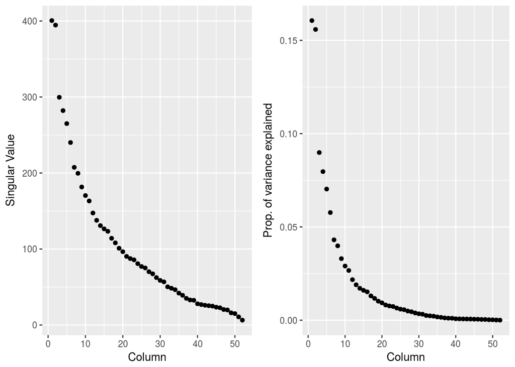

```r
svd1 <- svd(scale(select(dataset,-c(classe, user_name))))
p1 <- qplot(x = seq_along(svd1$d),y = svd1$d, xlab = "Column", ylab = "Singular Value")
p2 <- qplot(x = seq_along(svd1$d),y = svd1$d^2/sum(svd1$d^2), xlab = "Column", ylab = "Prop. of variance explained")
grid.arrange(p1,p2, ncol = 2)
```

Number of PCA components explaining 95% variation in dataset

```r
pp<-preProcess(dataset,method="pca",thresh=0.95)
pp
```

```
## Created from 19216 samples and 54 variables
##
## Pre-processing:
##   - centered (52)
##   - ignored (2)
##   - principal component signal extraction (52)
##   - scaled (52)
##
## PCA needed 25 components to capture 95 percent of the variance
```

The number of PCA components is 25 for explaining 95% of data. Which are 50% of 53 dataset features, we wont use them as they won’t affect much and and would cause less interpretability.

# 5. Classification models

## Creating training and testing datasets

```r
set.seed(12345)
inTrain <- createDataPartition(dataset$classe, p = 0.7, list = F)
training <- dataset[inTrain,]
testing <- dataset[-inTrain,]
nrow(training)
```

```
## [1] 13453
```

```r
nrow(testing)
```

```
## [1] 5763
```

## 1. Support Vector Machine

Building SVM with k-fold cross validation with tuning parameters cost (0.1,1,10) and gamma (0.1,0.5,1)

```r
## SVM
svm_tune <- tune(svm, classe~., data = training[sample(nrow(training), 3000),],ranges=list(cost=10^(-1:1), gamma=c(0.1,.5,1)))
```

```r
summary(svm_tune)
```

```
##
## Parameter tuning of 'svm':
##
## - sampling method: 10-fold cross validation
##
## - best parameters:
##  cost gamma
##    10   0.1
##
## - best performance: 0.07
##
## - Detailed performance results:
##   cost gamma     error dispersion
## 1  0.1   0.1 0.4666667 0.03953433
## 2  1.0   0.1 0.0910000 0.02131770
## 3 10.0   0.1 0.0700000 0.01186342
## 4  0.1   0.5 0.7113333 0.02450498
## 5  1.0   0.5 0.2626667 0.02232200
## 6 10.0   0.5 0.2400000 0.02287918
## 7  0.1   1.0 0.7113333 0.02450498
## 8  1.0   1.0 0.4230000 0.03191230
## 9 10.0   1.0 0.3950000 0.03178827
```

```r
model.svm <- svm_tune$best.model;
model.svm
```

```
##
## Call:
## best.tune(method = svm, train.x = classe ~ ., data = training[sample(nrow(training),
##     3000), ], ranges = list(cost = 10^(-1:1), gamma = c(0.1,
##     0.5, 1)))
##
##
## Parameters:
##    SVM-Type:  C-classification
##  SVM-Kernel:  radial
##        cost:  10
##       gamma:  0.1
##
## Number of Support Vectors:  2308
```

We select best model having high accuracy. Which has cost = 10 and gamma = 0.1

Calculating out of sample error using confusionMatrix

```r
confusionMatrix(testing$classe, predict(model.svm, testing))
```

```
## Confusion Matrix and Statistics
##
##           Reference
## Prediction    A    B    C    D    E
##          A 1601   15    2    1   22
##          B   50 1020   23    2   20
##          C    9   50  895   28   23
##          D    2    3   53  850   36
##          E    4    7   16    7 1024
##
## Overall Statistics
##
##                Accuracy : 0.9353
##                  95% CI : (0.9286, 0.9415)
##     No Information Rate : 0.2891
##     P-Value [Acc > NIR] : < 2.2e-16
##
##                   Kappa : 0.9181
##  Mcnemar's Test P-Value : 3.094e-13
##
## Statistics by Class:
##
##                      Class: A Class: B Class: C Class: D Class: E
## Sensitivity            0.9610   0.9315   0.9050   0.9572   0.9102
## Specificity            0.9902   0.9796   0.9770   0.9807   0.9927
## Pos Pred Value         0.9756   0.9148   0.8905   0.9004   0.9679
## Neg Pred Value         0.9842   0.9839   0.9802   0.9921   0.9785
## Prevalence             0.2891   0.1900   0.1716   0.1541   0.1952
## Detection Rate         0.2778   0.1770   0.1553   0.1475   0.1777
## Detection Prevalence   0.2847   0.1935   0.1744   0.1638   0.1836
## Balanced Accuracy      0.9756   0.9556   0.9410   0.9690   0.9514
```

we get the accuray of **0.9353** and Kappa = **0.9181**.

## 2. Random Forest

Building Random Forest with k-fold cross validation having 10 folds

```r
control <- trainControl(method="cv", number=10)
model.rfcvo <- train(classe~., method = "rf" ,data = training,ntree = 20,  trControl = control)
model.rfcvo
```

```
## Random Forest
##
## 13453 samples
##    53 predictors
##     5 classes: 'A', 'B', 'C', 'D', 'E'
##
## No pre-processing
## Resampling: Cross-Validated (10 fold)
## Summary of sample sizes: 12107, 12108, 12108, 12108, 12109, 12108, ...
## Resampling results across tuning parameters:
##
##   mtry  Accuracy   Kappa
##    2    0.9846125  0.9805299
##   29    0.9891472  0.9862694
##   57    0.9855796  0.9817548
##
## Accuracy was used to select the optimal model using  the largest value.
## The final value used for the model was mtry = 29.
```

```r
confusionMatrix(testing$classe,predict(model.rfcvo, testing))
```

```
## Confusion Matrix and Statistics
##
##           Reference
## Prediction    A    B    C    D    E
##          A 1637    2    1    0    1
##          B   20 1087    7    0    1
##          C    1    7  995    2    0
##          D    0    0   13  929    2
##          E    1    2    2    3 1050
##
## Overall Statistics
##
##                Accuracy : 0.9887
##                  95% CI : (0.9856, 0.9913)
##     No Information Rate : 0.2879
##     P-Value [Acc > NIR] : < 2.2e-16
##
##                   Kappa : 0.9857
##  Mcnemar's Test P-Value : NA
##
## Statistics by Class:
##
##                      Class: A Class: B Class: C Class: D Class: E
## Sensitivity            0.9867   0.9900   0.9774   0.9946   0.9962
## Specificity            0.9990   0.9940   0.9979   0.9969   0.9983
## Pos Pred Value         0.9976   0.9749   0.9900   0.9841   0.9924
## Neg Pred Value         0.9947   0.9976   0.9952   0.9990   0.9991
## Prevalence             0.2879   0.1905   0.1766   0.1621   0.1829
## Detection Rate         0.2841   0.1886   0.1727   0.1612   0.1822
## Detection Prevalence   0.2847   0.1935   0.1744   0.1638   0.1836
## Balanced Accuracy      0.9929   0.9920   0.9876   0.9958   0.9973
```

We get the accuracy of **0.9887** and kappa = **0.9857**.

Since **accuray of random forest is much higher than SVM** we will use random forest as our prediction algorithm on prediction dataset given by coursera.

If accuracies of SVM and random forest are comparable then we would have ensembled(combine) them to achieve much robust prediction algorithm.

# 6. Applying prediction algorithm

we apply the random forest prediction algorithm on prediction dataset given by coursera

```r
predict(model.rfcvo, dataPredict)
```

```
##  [1] B A B A A E D B A A B C B A E E A B B B
## Levels: A B C D E
```